# Monte_Carlo_power_mediation

Vandermeulen Sam

2024-05-13

# Monte-Carlo simulations for empirical power of path coefficients and indirect effect

## Introduction

A PDF containing my master’s thesis in experimental psychology has been uploaded to this repository (Vandermeulen et al., 2023). It delves into the impact of (multi)collinearity on the empirical power of path coefficients within a serial mediation model. Utilizing a simulation approach, I investigated these effects, developing a user-defined function to facilitate the process. Additionally, the thesis elucidates the circumstances under which empirical power diminishes in a (multi)collinear setting. Furthermore, it compares the Monte Carlo approach to classical power calculations, specifically Sobel’s method, albeit this section has been omitted from the function.

The model is as follows:

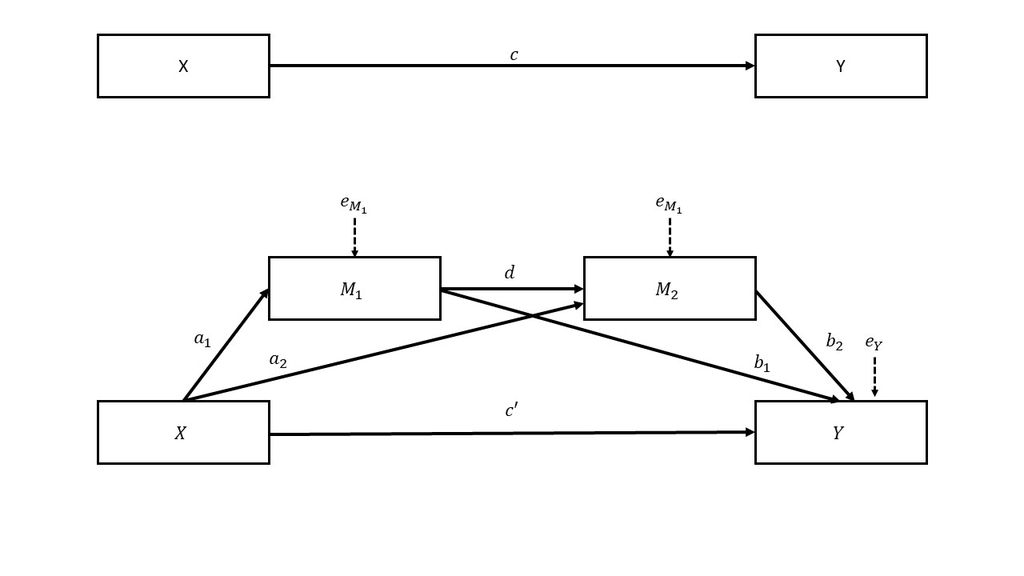

### On the function

The user-defined function, power.simulation(), is tailored to assess the empirical power of path coefficients in a serial mediation model featuring two mediators and no moderators, as outlined in the accompanying file. Serial mediation is determined using Hayes’ method, a regression-based technique that dissects the mechanisms between independent and dependent variables. This method quantifies both direct and indirect effects through mediators, offering valuable insights into intricate causal relationships (Rijnhart et al., 2021; MacKinnon et al., 2019; Have & Joffe, 2010).

The function itself is straightforward; it generates data for each simulation iteration based on predefined values for path coefficients, intercepts, and residual standard deviation. A comprehensive explanation of the methodology is provided within the thesis. Although the model tested in this instance features a binary independent variable, it can be effortlessly adjusted as needed.

## Code with annotations

To run this function successfully, it’s essential to have several R packages installed. These packages provide essential functionalities for data manipulation and statistical analysis.

```r
install.packages("semTools", repos = "http://cran.us.r-project.org")
install.packages("MKpower", repos = "http://cran.us.r-project.org")
install.packages("lavaan", repos = "http://cran.us.r-project.org")
```

```r
library(lavaan); library(semTools);library(MKpower)
```

```r
# numeric values should be filled in between parentheses
# path coefficients
a_1 <- c(); a_2 <- c(); c_prime <- c()
d <- c(); b_1 <- c(); b_2 <- c()
# intercepts
i1 <- c(); i2 <- c(); i3 <- c()
# residual standard deviation
sigma_m1 <- c(); sigma_m2 <- c(); sigma_m3 <- c()
# sample size
n <- c()
# chance of being female (1)
k <- c()
# number of simulations
NumSim   <-  c()
```

This function is flexible and adaptable, capable of accommodating both single and multiple simulation scenarios. For a specific simulation scenario, users can obtain numeric values for particular path coefficients, intercepts, residual standard deviation, sample size,…

Additionally, by utilizing the expand.grid() function, a data frame can be generated containing a row for each combination of the supplied factors. A factor here is a numeric vector for e.g.: path coefficient, intercept,… this vector allow us to research increasing collinearity between predictors. This versatility empowers researchers to investigate a wide range of experimental conditions and hypotheses within their serial mediation models.

```r
# make a grid with a row for every possible simulation scenario.
grid <- data.frame(expand.grid(a_1, a_2, c_prime, d, b_1, b_2, i1, i2,
                               i3, sigma_m1, sigma_m2, sigma_m3))
# name grid columns
colnames(grid) <- c("a_1", "a_2", "c_prime", "d", "b_1",
                    "b_2", "i1", "i2", "i3", "sigma_m1",
                    "sigma_m2", "sigma_m3")
```

Now that a data frame has been constructed with all the necessary simulation scenarios, is it time to initialize the function.

The functions arguments are the parameters that were used to make the grid, plus “n”, “k” and “NumSim”. Keep in mind that the serial mediation model used here had a binary independent variable (“sex”). Future researchers can change this in their code and possibly leave the “k” parameter out of the arguments.

```r
# define function power.simulation(arguments)
power.simulation <- function(a_1, a_2, c_prime, d, b_1,
                             b_2, i1, i2, i3, sigma_m1, sigma_m2,
                             sigma_m3, n, k, NumSim)
{
  # Monte-Carlo simulation of power of coefficients and indirect effect
  pval.a_1     <- rep(NA, NumSim); pval.a_2     <- rep(NA, NumSim)
  pval.d       <- rep(NA, NumSim); pval.b_1     <- rep(NA, NumSim)
  pval.b_2     <- rep(NA, NumSim); pval.c_prime <- rep(NA, NumSim)
  intdes <- matrix(0, NumSim, 2)
  indicatorIE <- vector("numeric", NumSim)
  # start loop (empirical power via MC simulations)
  for(i in 1:NumSim)
  {
   set.seed(i)
    # create first binary predictor (Sex)
    df$X <- data.frame(rbinom(n, 1, k)
    # create data
    df$M_1 <- i1 + a_1*df$X + rnorm(n, 0, sigma_m1)
    df$M_2 <- i2 + a_2*df$X +       d*df$M_1 + rnorm(n, 0, sigma_m2)
    df$Y   <- i3 + c_prime*df$X + b_1*df$M_1 + b_2*df$M_2 + rnorm(n, 0, sigma_m3)
    colnames(df) <- c("X", "M_1", "M_2", 'Y')
    # fit linear regression models on the simulated data
    fit.1 <- lm(df$M_1 ~ df$X)
    fit.2 <- lm(df$M_2 ~ df$X + df$M_1)
    fit.3 <- lm(df$Y ~ df$X + df$M_1 + df$M_2)
    # MC Confidence Interval for the indirect effect through both mediators
    model <- "
      M_1 ~ a1*X
      M_2 ~ a2*X + d21*M_1
      Y ~ cp*X + b1*M_1 + b2*M_2
      ind_eff := a1*d21*b2
      "
    fit <- sem(model = model, data = df)
    # extract the upper and lower bound
    intdes[i,1] <- monteCarloCI(fit)[1,2]
    intdes[i,2] <- monteCarloCI(fit)[1,3]
    # indicator function
    indicatorIE[i] <- ifelse(((intdes[i,1] < 0) & (intdes[i,2] > 0)),0,1)
    # save p-values
    pval.a_1[i] <- coef(summary(fit.1))[2,4]
    pval.a_2[i] <- coef(summary(fit.2))[2,4]
    pval.d[i] <- coef(summary(fit.2))[3,4]
    pval.b_1[i] <- coef(summary(fit.3))[3,4]
    pval.b_2[i] <- coef(summary(fit.3))[4,4]
    pval.c_prime[i] <- coef(summary(fit.3))[2,4]
  }
  # store power for MC
  power.a_1 <- mean(pval.a_1 < 0.05); power.a_2  <- mean(pval.a_2 < 0.05)
  power.b_1 <- mean(pval.b_1 < 0.05); power.b_2 <- mean(pval.b_2 < 0.05)
  power.d <- mean(pval.d < 0.05); power.c_prime <- mean(pval.c_prime < 0.05)
  power.IE <- mean(indicatorIE)
  # list results. Listing is done for later graphing using GGPlot2
  results <- list("power.a_1" = power.a_1, "power.a_2" = power.a_2,
                  "power.b_1" = power.b_1, "power.b_2" = power.b_2,
                  "power.d" = power.d, "power.c_prime" = power.c_prime,
                  "power.IE" = power.IE)
  return(results)
}
```

Now that the function is initialized, it becomes possible to apply it across all rows within the data frame capturing the simulation scenarios. Each row corresponds to a distinct simulation scenario, facilitating comprehensive exploration and analysis.

```r
results.power <- pbapply::pbmapply(power.simulation, a_1 = grid$a_1, a_2 = grid$a_2,
                                   c_prime = grid$c_prime, d = grid$d, b_1 = grid$b_1,
                                   b_2 = grid$b_2, i1 = grid$i1, i2 = grid$i2, i3 = grid$i3,
                                   sigma_m1 = grid$sigma_m1, sigma_m2 = grid$sigma_m2,
                                   sigma_m3 = grid$sigma_m3)
```

The following code unlists the compiled results for each simulation scenario, showcasing the empirical power per path coefficient and indirect effect. After unlisting, the grid can be used to make graphs using i.e. GGPlot2.

```r
# unlist
grid$power.a_1      <- unlist(results.power[seq(1, length(results.power), 7)])
grid$power.a_2      <- unlist(results.power[seq(2, length(results.power), 7)])
grid$power.b_1      <- unlist(results.power[seq(3, length(results.power), 7)])
grid$power.b_2      <- unlist(results.power[seq(4, length(results.power), 7)])
grid$power.d        <- unlist(results.power[seq(5, length(results.power), 7)])
grid$power.c_prime  <- unlist(results.power[seq(6, length(results.power), 7)])
grid$power.IE       <- unlist(results.power[seq(7, length(results.power), 7)])
```

## Sources

Rijnhart, J. J., Lamp, S. J., Valente, M. J., MacKinnon, D. P., Twisk, J. W. R., & Heymans, M. W. (2021). Mediation analysis Methods used in observational research: A scoping review and recommendations. BMC Medical Research Methodology, 21(1). https://doi.org/10.1186/s12874-021-01426-3

MacKinnon, D. P., Valente, M. J., & Gonzalez, O. R. (2019). The correspondence between causal and traditional mediation analysis: The link is the mediator by treatment interaction. Prevention Science, 21(2), 147–157. https://doi.org/10.1007/s11121-019-01076-4

Vandermeulen, S., Cummins, J., De Neve, J., & Kaya, I. (2023). Power Calculations via Monte-Carlo Simulations in Mediation Analysis with an Application to Sex Differences in Trait Anxiety for Young Americans.

Have, T. R. T., & Joffe, M. M. (2010). A review of causal estimation of effects in mediation analyses. Statistical Methods in Medical Research, 21(1), 77–107. https://doi.org/10.1177/0962280210391076